# Practical Machine Learning Course Project

Aaron Quan

December 11, 2016

## Importing and Modifying the Data

The first step is to import the data set. As there are several missing values, this ensures that all of them show up as “NA” in the data frame.

```r
pml.train <- read.csv("./pml-training.csv", na.strings=c("#DIV/0!","NA"))
pml.test <- read.csv("./pml-testing.csv", na.strings=c("#DIV/0!","NA"))
```

Next, I examine the training sets to determine what variables had missing values.

```r
apply(is.na(pml.train), 2, sum)
```

[output not shown]

```r
# Remove all columns with the majority of obvsecations being N/A
n <- dim(pml.train)[1]
n.test <- dim(pml.test)[1]
pml.train2 <- pml.train[,(apply(is.na(pml.train), 2, sum) < .5*n)]
pml.test2 <- pml.test[,apply(is.na(pml.test), 2, sum) < .5*n.test]

# Removing all columns with identification info
pml.train2 <- pml.train2[,-(1:7)]
pml.test2 <- pml.test2[,-(1:7)]
```

## Data Partitioning for Cross Validation

Here, I prepare the data set for cross validation by splitting the training set into subsets: 60% for the training and 40% for the testing.

```r
library(caret)
library(randomForest)

p = dim(pml.test2)[2]
inTrain  <- createDataPartition(pml.train2$classe, p=0.60, list=FALSE)

train.part <- pml.train2[inTrain, ]
test.part  <- pml.train2[-inTrain, ]
```

## Processing Random Forest Model

For this problem, I settled on the random forest as it is a fairly accurate method for classification problems. One of the things I needed to consider is how many trees to use. To do that, I looked at the accuracy measure based on the recommended tuned parameter of the square root of the number of predictors in the training set.

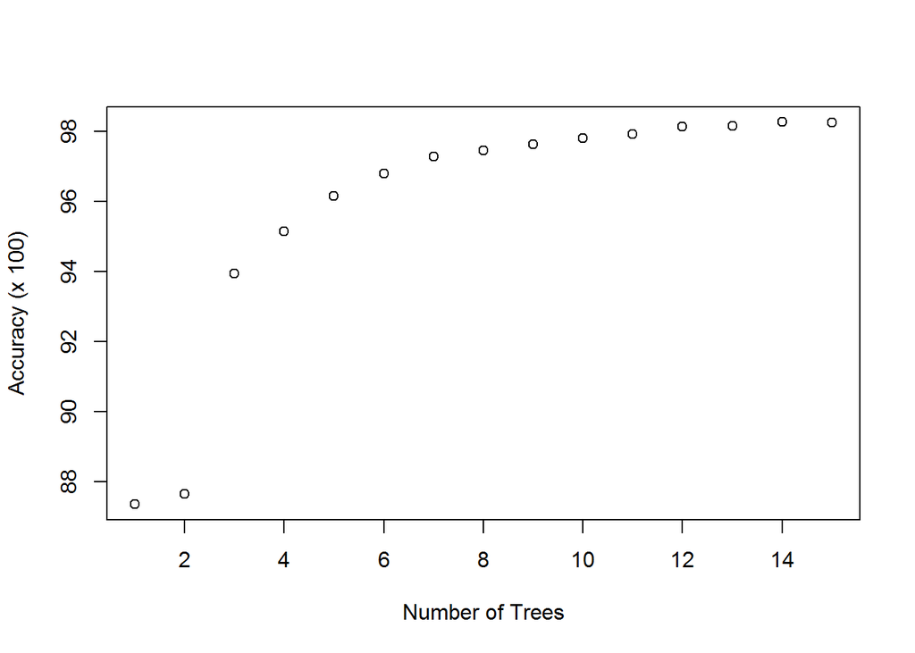

After examining the plot, I decided that 7 is the ideal number as the increase in accuracy levels off after that point. The random forest model is now performed on the training subset.

```r
mtry <- sqrt(ncol(train.part))
tunegrid <- expand.grid(.mtry=mtry)
modfit <- train(classe ~., data=train.part, method="rf", ntree=7, tuneGrid=tunegrid)
```

## Cross Validation on Test Subset

Cross validation is performed on the testing subset using this fitted random forest model.

```r
predict.pml.test <- predict(modfit,newdata=test.part)
cm.xv <- confusionMatrix(predict.pml.test, test.part$classe)
cm.xv
```

[output not shown]

## Quiz Predictions

In this part, I apply the fitted model to the test set for the quiz.

```r
pred.quiz <- predict(modfit, newdata=pml.test2)
pred.quiz
```

[output not shown]